# activity_tracking

1. Introduction
2. Processing
3. Analysis  
   3.1 Daily activity tracking  
   3.2 Daily activity intensity  
   3.3 Sleep activity tracking  
   3.4 Weight information tracking  
   3.5 Minutes of average total daily activity  
   3.6 Hourly steps distribution  
   3.7 Activity intensity distribution
4. Conclusions

# Introduction

Bellabeat is a high-tech company that manufactures health-focused smart products and Urska Srsen, Bellabeat's cofounder, asked to analyze smart device usage data in order to gain insight on how people already use smart devices. By using this information the company is looking for recommendations that would help Bellabeat marketing strategy.

The data available for the analysis has been generated thanks to Amazon Mechanical Turk.

# Processing

```python
%%capture
!pip install pandas
!pip install matplotlib

import pandas as pd
import matplotlib.pyplot as plt
```

```python
# Datasets are being imported
# Notes: - "dailyActivity" has the same information as "dailySteps", "dailyIntensities" and "dailyCalories"
#          so it's not needed to import the other three datasets

dailyActivity = pd.read_csv(r'.\Dataset\archive\Fitabase Data 4.12.16-5.12.16\dailyActivity.csv')
hourlyIntensities = pd.read_csv(r".\Dataset\archive\Fitabase Data 4.12.16-5.12.16\hourlyIntensities.csv")
hourlySteps = pd.read_csv(r".\Dataset\archive\Fitabase Data 4.12.16-5.12.16\hourlySteps.csv")
sleepDay = pd.read_csv(r".\Dataset\archive\Fitabase Data 4.12.16-5.12.16\sleepDay.csv")
weightLogInfo = pd.read_csv(r".\Dataset\archive\Fitabase Data 4.12.16-5.12.16\weightLogInfo.csv")

# Dropping duplicates

dailyActivity = dailyActivity.drop_duplicates()
hourlyIntensities = hourlyIntensities.drop_duplicates()
hourlySteps = hourlySteps.drop_duplicates()
sleepDay = sleepDay.drop_duplicates()
weightLogInfo = weightLogInfo.drop_duplicates()

# Dropping rows with all missing values

dailyActivity.dropna(how='all')
hourlyIntensities.dropna(how='all')
hourlySteps.dropna(how='all')
sleepDay.dropna(how='all')
weightLogInfo.dropna(how='all')
```

|  | Id | Date | WeightKg | WeightPounds | Fat | BMI | IsManualReport | LogId |
| --- | --- | --- | --- | --- | --- | --- | --- | --- |
| 0 | 1503960366 | 5/2/2016 11:59:59 PM | 52.599998 | 115.963147 | 22.0 | 22.650000 | True | 1462233599000 |
| 1 | 1503960366 | 5/3/2016 11:59:59 PM | 52.599998 | 115.963147 | NaN | 22.650000 | True | 1462319999000 |
| 2 | 1927972279 | 4/13/2016 1:08:52 AM | 133.500000 | 294.317120 | NaN | 47.540001 | False | 1460509732000 |
| 3 | 2873212765 | 4/21/2016 11:59:59 PM | 56.700001 | 125.002104 | NaN | 21.450001 | True | 1461283199000 |
| 4 | 2873212765 | 5/12/2016 11:59:59 PM | 57.299999 | 126.324875 | NaN | 21.690001 | True | 1463097599000 |
| ... | ... | ... | ... | ... | ... | ... | ... | ... |
| 62 | 8877689391 | 5/6/2016 6:43:35 AM | 85.000000 | 187.392923 | NaN | 25.440001 | False | 1462517015000 |
| 63 | 8877689391 | 5/8/2016 7:35:53 AM | 85.400002 | 188.274775 | NaN | 25.559999 | False | 1462692953000 |
| 64 | 8877689391 | 5/9/2016 6:39:44 AM | 85.500000 | 188.495234 | NaN | 25.610001 | False | 1462775984000 |
| 65 | 8877689391 | 5/11/2016 6:51:47 AM | 85.400002 | 188.274775 | NaN | 25.559999 | False | 1462949507000 |
| 66 | 8877689391 | 5/12/2016 6:42:53 AM | 84.000000 | 185.188300 | NaN | 25.139999 | False | 1463035373000 |

67 rows × 8 columns

# Analysis

```python
# There are 33 unique IDs

len(dailyActivity['Id'].unique())
```

```
33
```

```python
# The data has been taken in the time window between 4/12/2016 and 5/12/2016 (m/d/y)

min([pd.Timestamp(x) for x in dailyActivity['ActivityDate']])
```

```
Timestamp('2016-04-12 00:00:00')
```

```python
max([pd.Timestamp(x) for x in dailyActivity['ActivityDate']])
```

```
Timestamp('2016-05-12 00:00:00')
```

### Daily activity tracking

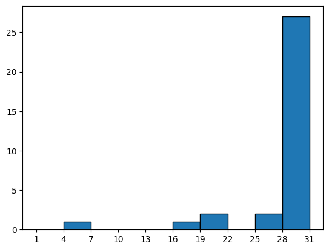

```python
#  Out of the 33 users, 27 have kept the device on for at least
#  28 days out of 31 (more than 90% of the whole time window).

daily_tracking = {}
for user in dailyActivity['Id'].unique():
    daily_tracking[user] = len(dailyActivity.query('Id == @user')['Id'])

fig1, ax1 = plt.subplots()

ax1.hist(daily_tracking.values(),
         edgecolor = "black",
         bins = [1,4,7,10,13,16,19,22,25,28,31])
plt.xticks([1,4,7,10,13,16,19,22,25,28,31]);
```